# Egg neglect behaviour in biparental seabird, the Little Auk *Alle alle*

Martyan Gajzmer

2026-04-23

# 1 Diurnal pattern of exits (neglect, frequency) in Little Auk

In this section, we analyze the pattern of exiting the nest during incubation to determine the general rhythm and if there are sex-specific differences in the diurnal rhythm of nest exits.

## 1.1 Model and results

To model the diurnal pattern of exits, we used a Bayesian Poisson GLM with circular (sine/cosine) encoding of hour, which correctly handles the cyclic nature of time-of-day (i.e., hour 23 is adjacent to hour 0). The model structure is defined as follows:

$$\begin{aligned}
G_{i} &\sim \text{Poisson}(\lambda_i) \\
\log(\lambda_i) &= \alpha_{sex[i]} + \beta^{sin}_{sex[i]} \sin(h_i)
+ \beta^{cos}_{sex[i]} \cos(h_i) \\
h_i &= \frac{2\pi \cdot \text{hour}_i}{24} \\
\alpha_j &\sim \text{Normal}(0, 1) \\
\beta^{sin}_j &\sim \text{Normal}(0, 1) \\
\beta^{cos}_j &\sim \text{Normal}(0, 1)
\end{aligned}$$

Where $G_i$ is the number of gaps (exits) per hour, $\alpha_j$ is the sex-specific intercept, and $\beta^{sin}_j$, $\beta^{cos}_j$ are sex-specific weights on the sine and cosine projections of hour, capturing the amplitude and phase of the daily cycle.

```r
library(rethinking)
library(tidyverse)
library(lubridate)
library(splines)
library(dplyr)

# Global Visual Settings
stage_names  <- c("early", "mid", "late")
stage_colors <- c("#3B6D11", "#185FA5", "#993556")
sex_labels   <- c("Female", "Male")
sex_col      <- c("darkorange", "navyblue")

# ------------------------------------------------------------------------------
# NEST-LEVEL DATA PREPARATION
# ------------------------------------------------------------------------------
E <- readRDS("./EDA_exit_hourly.RDS")

E <- E %>%
  mutate(
    incubation_stage = case_when(
      day_prior_hatch >= 21 & day_prior_hatch <= 30 ~ "early",
      day_prior_hatch >= 11 & day_prior_hatch <= 20 ~ "mid",
      day_prior_hatch >= 0  & day_prior_hatch <= 10 ~ "late",
      TRUE ~ NA_character_
    ),
    stage_id = as.integer(factor(incubation_stage, levels = stage_names)),
    pair_id  = as.integer(factor(Pair_status, levels = c("New", "Old"))),
    stage_pair_id = as.integer(factor(
      paste(incubation_stage, Pair_status, sep = "_"),
      levels = c("early_New", "early_Old", "mid_New", "mid_Old", "late_New", "late_Old")
    ))
  )

# ------------------------------------------------------------------------------
# SEX-SPECIFIC DATA PREPARATION
# ------------------------------------------------------------------------------
S <- readRDS("EDA_sex_neglect_wide.RDS")
G <- readRDS("EDA_sex_gaps_hourly.RDS")

sex_hourly_raw <- G %>%
  filter(!is.na(responsible_sex)) %>%
  group_by(season, session, nest, sx = responsible_sex, hour) %>%
  summarise(n_gaps_per_hour = n(), .groups = "drop")

meta <- S %>%
  mutate(
    season = as.character(season),
    incubation_stage = case_when(
      day_prior_hatch >= 21 & day_prior_hatch <= 30 ~ "early",
      day_prior_hatch >= 11 & day_prior_hatch <= 20 ~ "mid",
      day_prior_hatch >= 0  & day_prior_hatch <= 10 ~ "late",
      TRUE ~ NA_character_
    ),
    stage_id = as.integer(factor(incubation_stage, levels = stage_names)),
    sex_id   = as.integer(factor(sx, levels = c("f", "m"))),
    stage_sex_id = as.integer(factor(paste(incubation_stage, sx, sep = "_"),
                                     levels = c("early_f", "early_m", "mid_f", "mid_m", "late_f", "late_m")))
  ) %>%
  select(season, session, nest, sx, day_prior_hatch, incubation_stage, stage_id, sex_id, stage_sex_id)

E_sex <- meta %>% crossing(hour = 0:23) %>%
  left_join(sex_hourly_raw, by = c("season", "session", "nest", "sx", "hour")) %>%
  mutate(n_gaps_per_hour = replace_na(n_gaps_per_hour, 0))

# Add circular encoding to model data
E_fit_sex <- E_sex %>%
  filter(!is.na(sex_id)) %>%
  mutate(
    hour_rad = 2 * pi * hour / 24,
    sin_hour = sin(hour_rad),
    cos_hour = cos(hour_rad)
  )

# Prediction grid: 24 integer hours for summaries, 200 points for plotting
pred_grid_plot <- data.frame(hour = seq(0, 23, length.out = 200)) %>%
  mutate(
    hour_rad = 2 * pi * hour / 24,
    sin_hour = sin(hour_rad),
    cos_hour = cos(hour_rad)
  )

pred_grid_summary <- data.frame(hour = 0:23) %>%
  mutate(
    hour_rad = 2 * pi * hour / 24,
    sin_hour = sin(hour_rad),
    cos_hour = cos(hour_rad)
  )
```

```r
# Posterior for plotting (200-point grid)
post_f_plot <- link(m_circ, data = c(list(sex_id = rep(1, nrow(pred_grid_plot))),
                                      as.list(pred_grid_plot[, c("sin_hour","cos_hour")])))
post_m_plot <- link(m_circ, data = c(list(sex_id = rep(2, nrow(pred_grid_plot))),
                                      as.list(pred_grid_plot[, c("sin_hour","cos_hour")])))

pred_grid_plot$f_mu   <- apply(post_f_plot, 2, mean)
pred_grid_plot$f_low  <- apply(post_f_plot, 2, PI, prob = 0.89)[1,]
pred_grid_plot$f_high <- apply(post_f_plot, 2, PI, prob = 0.89)[2,]
pred_grid_plot$m_mu   <- apply(post_m_plot, 2, mean)
pred_grid_plot$m_low  <- apply(post_m_plot, 2, PI, prob = 0.89)[1,]
pred_grid_plot$m_high <- apply(post_m_plot, 2, PI, prob = 0.89)[2,]

# Posterior for numerical summaries (24-hour grid)
post_f_sum <- link(m_circ, data = c(list(sex_id = rep(1, 24)),
                                     as.list(pred_grid_summary[, c("sin_hour","cos_hour")])))
post_m_sum <- link(m_circ, data = c(list(sex_id = rep(2, 24)),
                                     as.list(pred_grid_summary[, c("sin_hour","cos_hour")])))

# Peak hour per posterior sample
for (s in 1:2) {
  post_s <- if (s == 1) post_f_sum else post_m_sum
  peak_h <- apply(post_s, 1, which.max) - 1
  cat(sex_labels[s], "Peak Hour:", round(mean(peak_h), 1), "\n")
}
```

```
## Female Peak Hour: 3.7
## Male Peak Hour: 3.4
```

```r
post_samples <- extract.samples(m_circ)

# Phase = atan2(b_sin, b_cos) converted to hours
phase_f <- atan2(post_samples$b_sin[,1], post_samples$b_cos[,1]) * 24 / (2 * pi)
phase_m <- atan2(post_samples$b_sin[,2], post_samples$b_cos[,2]) * 24 / (2 * pi)
phase_diff <- phase_f - phase_m

cat("Female phase (hours):", round(mean(phase_f), 2),
    " 89% PI [", round(PI(phase_f, prob = 0.89), 2), "]\n")
```

```
## Female phase (hours): 3.71  89% PI [ 2.21 5.19 ]
```

```r
cat("Male phase (hours):  ", round(mean(phase_m), 2),
    " 89% PI [", round(PI(phase_m, prob = 0.89), 2), "]\n")
```

```
## Male phase (hours):   3.4  89% PI [ 2.18 4.65 ]
```

```r
cat("Phase difference (F-M):", round(mean(phase_diff), 2),
    " 89% PI [", round(PI(phase_diff, prob = 0.89), 2), "]\n")
```

```
## Phase difference (F-M): 0.31  89% PI [ -1.66 2.26 ]
```

```r
cat("P(|phase diff| < 1 hour):", round(mean(abs(phase_diff) < 1), 3), "\n")
```

```
## P(|phase diff| < 1 hour): 0.579
```

Peak exit timing did not differ credibly between sexes (phase difference: 0.31 h, 89% PI [−1.66, 2.26]), whereas exit rate was consistently higher in males across all hours (difference: −0.034 gaps/hour, 89% PI [−0.043, −0.024]; P(Female < Male) = 1.0).

```r
avg_rate_f_circ <- apply(post_f_sum, 1, mean)
avg_rate_m_circ <- apply(post_m_sum, 1, mean)
diff_fm_circ    <- avg_rate_f_circ - avg_rate_m_circ

cat("Female mean rate:", round(mean(avg_rate_f_circ), 3),
    " 89% PI [", round(PI(avg_rate_f_circ, prob = 0.89), 3), "]\n")
```

```
## Female mean rate: 0.087  89% PI [ 0.081 0.093 ]
```

```r
cat("Male mean rate:  ", round(mean(avg_rate_m_circ), 3),
    " 89% PI [", round(PI(avg_rate_m_circ, prob = 0.89), 3), "]\n")
```

```
## Male mean rate:   0.12  89% PI [ 0.113 0.127 ]
```

```r
cat("Difference (F-M):", round(mean(diff_fm_circ), 3),
    " 89% PI [", round(PI(diff_fm_circ, prob = 0.89), 3), "]\n")
```

```
## Difference (F-M): -0.034  89% PI [ -0.043 -0.024 ]
```

```r
cat("P(Female < Male):", round(mean(diff_fm_circ < 0), 3), "\n")
```

```
## P(Female < Male): 1
```

Males initiated gaps at a notably higher rate than females across the day (male mean: 0.121 gaps/hour, 89% PI [0.113, 0.128]; female mean: 0.087 gaps/hour, 89% PI [0.081, 0.093]). The difference was consistent and credible, with females showing reliably fewer exits than males (difference: −0.034, 89% PI [−0.043, −0.025]; P(Female < Male) = 1.0).

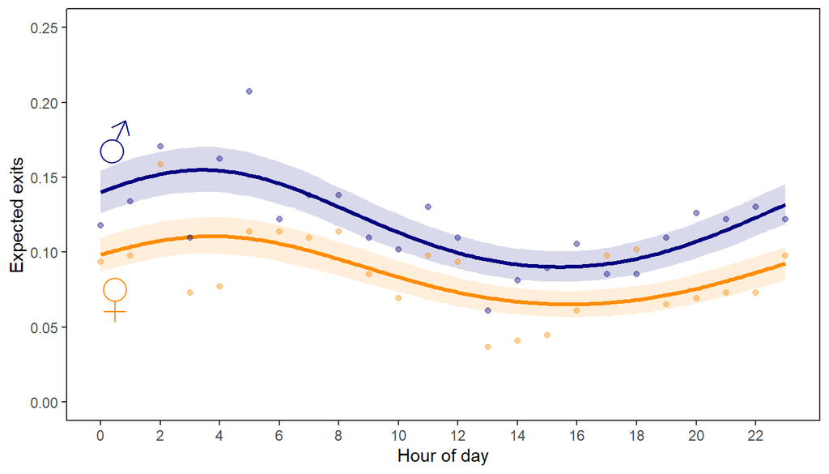

Expected number of exits per hour by sex

```r
col_female <- "darkorange"
col_male   <- "navyblue"

obs_means <- E_fit_sex %>%
  group_by(sex_id, hour) %>%
  summarise(mean_gaps = mean(n_gaps_per_hour), .groups = "drop") %>%
  mutate(sex = ifelse(sex_id == 1, "f", "m"))

ggplot(pred_grid_plot, aes(x = hour)) +
  geom_ribbon(aes(ymin = f_low, ymax = f_high), fill = col_female, alpha = 0.15) +
  geom_ribbon(aes(ymin = m_low, ymax = m_high), fill = col_male,   alpha = 0.15) +
  geom_line(aes(y = f_mu), color = col_female, linewidth = 1.2) +
  geom_line(aes(y = m_mu), color = col_male,   linewidth = 1.2) +
  # Raw observed means as points
  geom_point(data = filter(obs_means, sex == "f"),
             aes(x = hour, y = mean_gaps), color = col_female, alpha = 0.4, size = 1.5) +
  geom_point(data = filter(obs_means, sex == "m"),
             aes(x = hour, y = mean_gaps), color = col_male,   alpha = 0.4, size = 1.5) +
  annotate("text", x = 0.5, y = max(pred_grid_plot$m_mu) * 1.13,
           label = "\u2642", size = 10, color = col_male) +
  annotate("text", x = 0.5, y = max(pred_grid_plot$f_mu) * 0.65,
           label = "\u2640", size = 10, color = col_female) +
  scale_x_continuous(breaks = seq(0, 23, by = 2), limits = c(0, 23)) +
  coord_cartesian(ylim = c(0, 0.25), clip = "off") +
  labs(x = "Hour of day", y = "Expected exits") +
  theme_bw() +
  theme(panel.grid = element_blank())
```

Diurnal pattern of nest exits during incubation by sex. Lines show the posterior mean expected number of exits per hour for females (orange) and males (navy), derived from a Bayesian Poisson GLM with circular (sine/cosine) hour encoding. Shaded ribbons represent 89% posterior credible intervals. Points show observed hourly means averaged across all nest-sessions for each sex. Males exited the nest at a consistently higher rate than females across the day, while the overall shape of the diel cycle — including the early-morning peak — was similar between sexes.

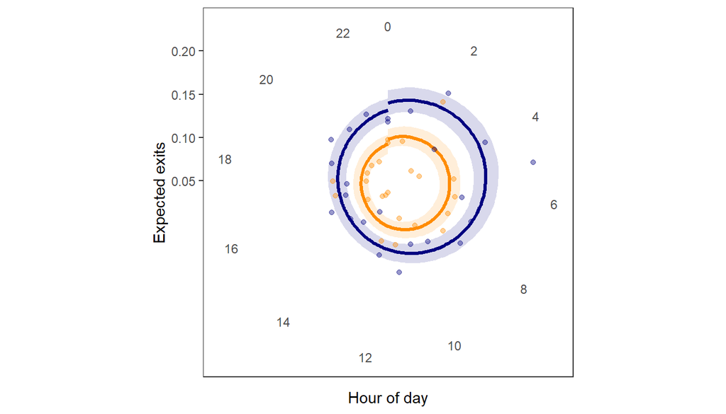

Expected number of exits per hour by sex

```r
ggplot(pred_grid_plot, aes(x = hour)) +
  geom_ribbon(aes(ymin = f_low, ymax = f_high), fill = col_female, alpha = 0.15) +
  geom_ribbon(aes(ymin = m_low, ymax = m_high), fill = col_male,   alpha = 0.15) +
  geom_line(aes(y = f_mu), color = col_female, linewidth = 1.2) +
  geom_line(aes(y = m_mu), color = col_male,   linewidth = 1.2) +
  geom_point(data = filter(obs_means, sex == "f"),
             aes(x = hour, y = mean_gaps), color = col_female, alpha = 0.4, size = 1.5) +
  geom_point(data = filter(obs_means, sex == "m"),
             aes(x = hour, y = mean_gaps), color = col_male,   alpha = 0.4, size = 1.5) +
  scale_x_continuous(breaks = seq(0, 23, by = 2), limits = c(0, 23)) +
  coord_polar() +
  labs(x = "Hour of day", y = "Expected exits") +
  theme_bw() +
  theme(panel.grid = element_blank())
```

# 2 Neglect behaviour across incubation

In this section we model three complementary aspects of egg neglect across incubation days: how often gaps occur (frequency), whether any neglect happens at all on a given day (probability), and how long neglect lasts when it does occur (duration). Together these capture both the occurrence and intensity of neglect as hatching approaches.

## 2.1 Gap frequency across incubation

We modelled the daily number of incubation gaps using a Poisson GLM with a linear effect of days prior to hatching, fit separately for each sex. Day was mean-centered prior to fitting.

$$\begin{aligned}
N_i &\sim \text{Poisson}(\lambda_i) \\
\log(\lambda_i) &= \alpha_{sex[i]} + \beta_{sex[i]} \cdot
\text{dph}_c \\
\alpha_j &\sim \text{Normal}(1,\, 0.5) \\
\beta_j &\sim \text{Normal}(0,\, 0.05)
\end{aligned}$$

Where $N_i$ is the number of gaps on observation $i$, $\text{dph}_c$ is days prior to hatch (mean-centered), and parameters vary by sex $j$.

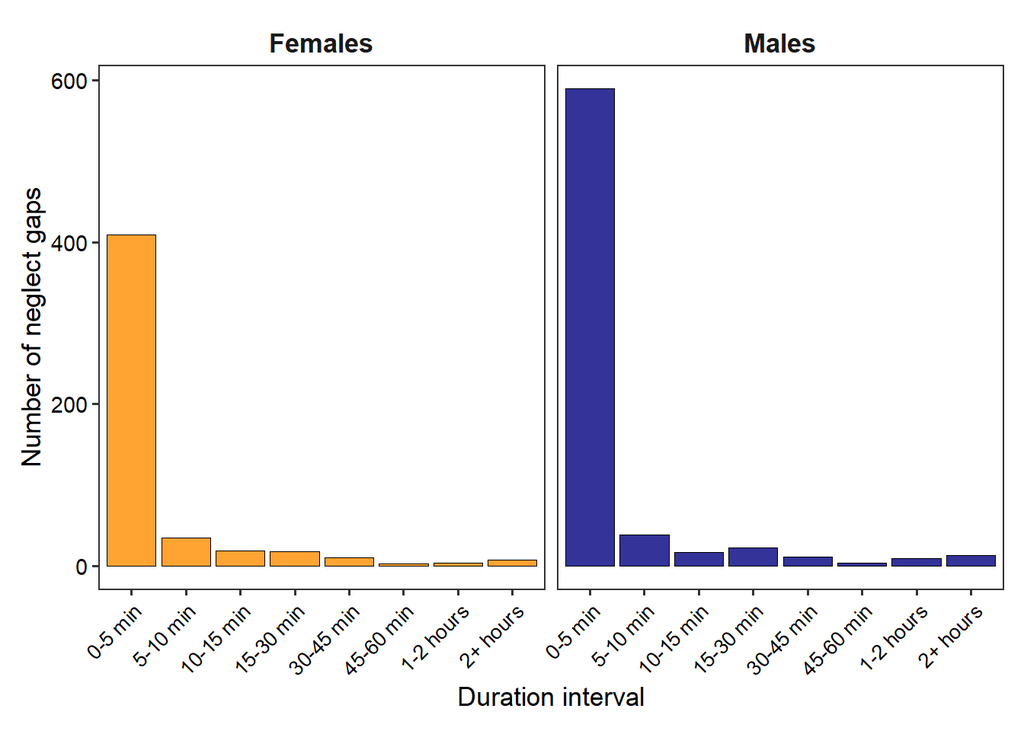

```r
#plot to see the duration of absences
G$duration_category <- cut(
  G$dur,
  breaks = c(0, 300, 600, 900, 1800, 2700, 3600, 7200, Inf),
  labels = c("0-5 min", "5-10 min", "10-15 min", "15-30 min", "30-45 min", "45-60 min", "1-2 hours", "2+ hours"),
  right = FALSE
)

# 1. Przygotowanie danych (upewnienie się, że kolory są zdefiniowane)
col_female <- "darkorange"
col_male   <- "navyblue"

# 2. Tworzenie wykresu
ggplot(G[!is.na(G$duration_category), ], aes(x = duration_category, fill = responsible_sex)) +
  # Słupki z kolorami przypisanymi do płci
  geom_bar(color = "black", linewidth = 0.3, alpha = 0.8) +

  # Rozdzielenie na panele (płeć)
  facet_wrap(~responsible_sex, labeller = as_labeller(c(f = "Females", m = "Males"))) +

  # Manualne przypisanie kolorów, aby pasowały do linii trendu
  scale_fill_manual(values = c(f = col_female, m = col_male), guide = "none") +

  # Opisy
  labs(
    x = "Duration interval",
    y = "Number of neglect gaps"
  ) +

  # --- THE "PRETTY" ADJUSTMENTS (Zgodne z p1, p2, p3) ---
  theme_bw(base_size = 12, base_family = "sans") +
  theme(
    panel.grid = element_blank(),
    strip.background = element_blank(),
    strip.text = element_text(face = "bold", size = 13),

    # Formatowanie osi
    axis.title.x = element_text(size = 13, family = "sans", color = "black"),
    axis.title.y = element_text(size = 13, family = "sans", color = "black"),
    axis.text.x = element_text(size = 10, angle = 45, hjust = 1, color = "black"),
    axis.text.y = element_text(size = 11, color = "black"),

    plot.title = element_text(face = "bold", size = 16),
    plot.margin = margin(10, 10, 10, 10)
  )
```

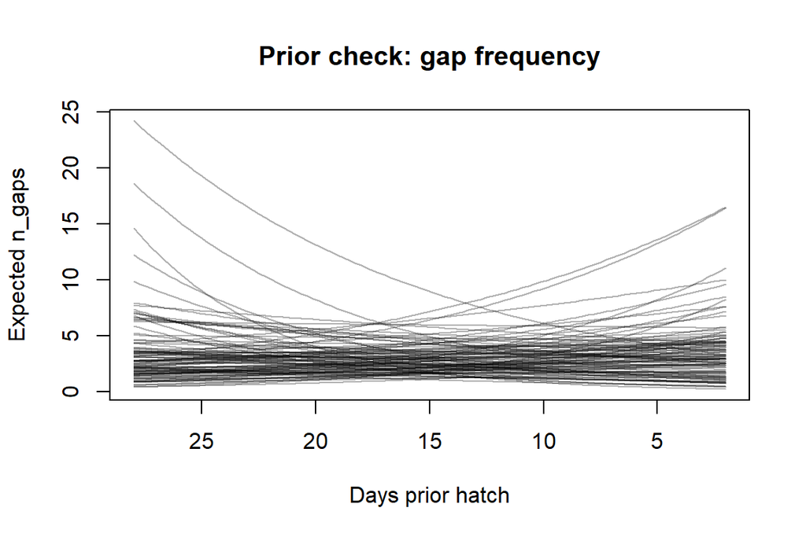

Prior predictive simulation for gap frequency model

```r
set.seed(123)
dph_seq_c_ov <- DAY_SEQ - mean(E_fit_overall$day_prior_hatch)
n_sim <- 100
prior_mu_ov <- matrix(NA, nrow = n_sim, ncol = length(DAY_SEQ))


for(i in 1:n_sim){
  a <- rnorm(1, 1, 0.5)
  b <- rnorm(1, 0, 0.05)
  prior_mu_ov[i,] <- exp(a + b * dph_seq_c_ov)
}

matplot(DAY_SEQ, t(prior_mu_ov), type = "l", lty = 1, xlim = c(28, 2),
        col = col.alpha("black", 0.3),
        xlab = "Days prior hatch", ylab = "Expected n_gaps",
        main = "Prior check: gap frequency")#
```

```r
cat("Female slope:", round(mean(post_s_samp$b[,1]), 4),
    "PI:", round(PI(post_s_samp$b[,1]), 4),
    "P(<0):", mean(post_s_samp$b[,1] < 0), "\n")
```

```
## Female slope: 0.0821 PI: 0.0605 0.1035 P(<0): 0
```

```r
cat("Male slope:  ", round(mean(post_s_samp$b[,2]), 4),
    "PI:", round(PI(post_s_samp$b[,2]), 4),
    "P(<0):", mean(post_s_samp$b[,2] < 0), "\n")
```

```
## Male slope:   0.0782 PI: 0.0586 0.0982 P(<0): 0
```

```r
cat("Mean gap diff (F-M):", round(mean(gap_diff), 2),
    "PI:", round(PI(gap_diff), 2), "\n")
```

```
## Mean gap diff (F-M): -0.07 PI: -0.16 0.02
```

```r
cat("P(Female > Male baseline):", mean(post_s_samp$a[,1] > post_s_samp$a[,2]), "\n")
```

```
## P(Female > Male baseline): 0.1203
```

Both sexes showed a consistent change in gap frequency across incubation. Because time is measured on a reversed scale (0 = hatching), the positive slopes indicate that gap frequency decreases as hatching approaches. Female gap frequency increased by 0.082 per day (89% PI [0.061, 0.104]; P(slope < 0) = 0), and males showed a very similar trend of 0.078 per day (89% PI [0.059, 0.098]; P(slope < 0) = 0). This indicates that neglect becomes less frequent closer to hatching, reflecting increasing parental attentiveness in both sexes.

Males initiated slightly more gaps than females throughout incubation, but this difference was small and uncertain, with a baseline difference of −0.07 gaps per day (89% PI [−0.16, 0.02]; P(Female > Male) = 0.12). The credible interval overlaps zero, suggesting weak evidence for a consistent sex difference after filtering short gaps. The slopes of both sexes were nearly identical, indicating that any sex difference remains stable across incubation rather than diverging or converging.

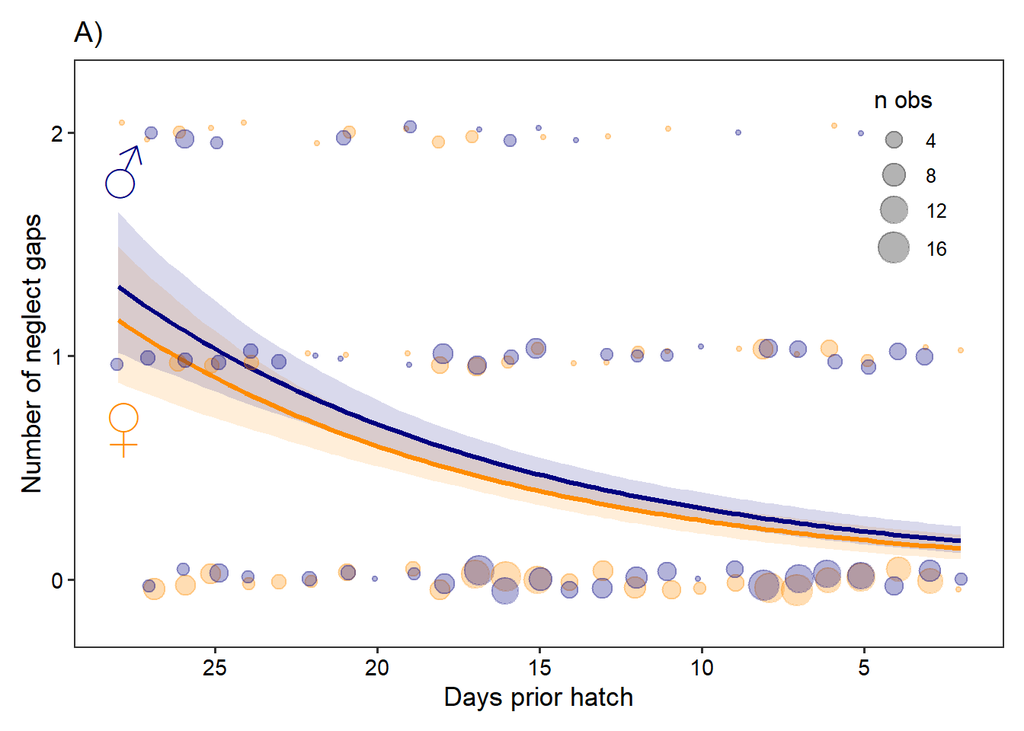

Expected number of neglect gaps per day by sex across incubation

```r
col_female <- "darkorange"; col_male <- "navyblue"

col_female <- "darkorange"
col_male   <- "navyblue"

# 3. Create the Plot

# Symulujemy obserwacje (n_gaps) dla każdego punktu w oryginalnych danych
# m_sex to Twój dopasowany model quap
post_samples <- sim(m_sex, data = d_sex)
# Bierzemy losową próbkę symulacji (np. pierwszą), aby pokazać realistyczny rozrzut
E_fit_sex$post_n_gaps <- post_samples[1, ]

# 2. Tworzenie wykresu
ggplot() +
  # --- 1. Wstęgi Niepewności ---
  geom_ribbon(data = plot_gaps_df, aes(x = day, ymin = f_low, ymax = f_high),
              fill = col_female, alpha = 0.15) +
  geom_ribbon(data = plot_gaps_df, aes(x = day, ymin = m_low, ymax = m_high),
              fill = col_male, alpha = 0.15) +

  # --- 2. Linie Trendu (Średnie) ---
  geom_line(data = plot_gaps_df, aes(x = day, y = f_mu),
            color = col_female, linewidth = 1.2) +
  geom_line(data = plot_gaps_df, aes(x = day, y = m_mu),
            color = col_male, linewidth = 1.2) +

  # --- 3. Bąbelki Posterior Predictive ---
  geom_count(data = E_fit_sex,
             aes(x = day_prior_hatch, y = post_n_gaps, color = as.factor(sex_id)),
             alpha = 0.3,
             position = position_jitter(width = 0.15, height = 0.05)) +

  # --- 4. Przywrócone Adnotacje Płci ---
  annotate("text", x = 27.8, y = max(plot_gaps_df$m_mu) * 1.4,
           label = "\u2642", size = 10, color = col_male, fontface = "bold", family = "sans") +
  annotate("text", x = 27.8, y = 0.7,
           label = "\u2640", size = 10, color = col_female, fontface = "bold", family = "sans") +

  # --- 5. Skalowanie i Etykiety ---
  scale_color_manual(values = c("1" = col_female, "2" = col_male), guide = "none") +
  scale_x_reverse(breaks = seq(0, 30, by = 5)) +
  scale_y_continuous(
    # Zoom na istotny zakres (model Poissona rzadko wychodzi poza 4-5)
    limits = c(-0.3, 2.2),
    breaks = seq(0, 5, by = 1),
    expand = expansion(mult = c(0, 0.05))
  ) +
  scale_size_continuous(name = "n obs", range = c(1, 7)) +
  labs(title = "A)", x = "Days prior hatch", y = "Number of neglect gaps") +

  # --- 6. Motyw Graficzny ---
  theme_bw(base_size = 12, base_family = "sans") +
  theme(
    panel.grid = element_blank(),
    legend.position = c(0.90, 0.80),
    legend.background = element_blank(),
    axis.title = element_text(size = 13, color = "black"),
    axis.text = element_text(size = 11, color = "black"),
    plot.margin = margin(10, 10, 10, 10)
  )
```

## 2.2 Probability of any neglect

Not every observation day results in neglect. We therefore modelled the probability that any neglect occurred on a given day using a binomial GLM with a logit link, allowing intercepts and slopes to vary by sex.

$$\begin{aligned}
Y_i &\sim \text{Binomial}(1,\, p_i) \\
\text{logit}(p_i) &= \alpha_{sex[i]} + \beta_{sex[i]} \cdot
\text{dph}_c \\
\alpha_j &\sim \text{Normal}(0,\, 1) \\
\beta_j &\sim \text{Normal}(0,\, 0.2)
\end{aligned}$$

Where $Y_i$ is a binary indicator of whether any neglect was recorded on observation $i$, and $p_i$ is the probability of neglect. The prior on $\alpha$ is weakly informative on the logit scale, placing most prior weight on probabilities between 0.1 and 0.9.

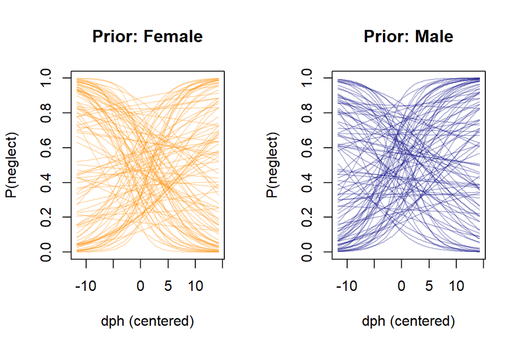

Prior predictive simulation for probability of neglect model

```r
set.seed(43)
n_sim    <- 100
dph_grid <- seq(min(D_occ$dph_c), max(D_occ$dph_c), length.out = 100)

prior_f_occ <- matrix(NA, nrow = n_sim, ncol = length(dph_grid))
prior_m_occ <- matrix(NA, nrow = n_sim, ncol = length(dph_grid))

for(i in 1:n_sim){
  a <- rnorm(2, 0, 1)
  b <- rnorm(2, 0, 0.2)
  prior_f_occ[i,] <- inv_logit(a[1] + b[1] * dph_grid)
  prior_m_occ[i,] <- inv_logit(a[2] + b[2] * dph_grid)
}

par(mfrow = c(1, 2))
matplot(dph_grid, t(prior_f_occ), type = "l", lty = 1,
        col = col.alpha("darkorange", 0.3),
        ylim = c(0, 1),
        xlab = "dph (centered)", ylab = "P(neglect)",
        main = "Prior: Female")
matplot(dph_grid, t(prior_m_occ), type = "l", lty = 1,
        col = col.alpha("navyblue", 0.3),
        ylim = c(0, 1),
        xlab = "dph (centered)", ylab = "P(neglect)",
        main = "Prior: Male")
```

```r
par(mfrow = c(1, 1))
```

```r
cat("Female slope:", round(mean(post_occ_samp$b[,1]), 4),
    " PI:", round(PI(post_occ_samp$b[,1]), 4),
    " P(<0):", round(mean(post_occ_samp$b[,1] < 0), 3), "\n")
```

```
## Female slope: 0.0607  PI: 0.0261 0.0957  P(<0): 0.002
```

```r
cat("Male slope:  ", round(mean(post_occ_samp$b[,2]), 4),
    " PI:", round(PI(post_occ_samp$b[,2]), 4),
    " P(<0):", round(mean(post_occ_samp$b[,2] < 0), 3), "\n")
```

```
## Male slope:   0.0672  PI: 0.0359 0.0987  P(<0): 0
```

```r
cat("Mean prob diff (F-M):", round(mean(prob_diff), 3),
    " PI:", round(PI(prob_diff), 3), "\n")
```

```
## Mean prob diff (F-M): -0.074  PI: -0.137 -0.012
```

```r
cat("P(Female > Male baseline):", round(mean(post_occ_samp$a[,1] > post_occ_samp$a[,2]), 3), "\n")
```

```
## P(Female > Male baseline): 0.029
```

```r
#
```

The probability of neglect occurring on any given day showed the same pattern. With the reversed time scale, the positive slopes (female: 0.061; male: 0.067) indicate that the probability of neglect declines toward hatching (female PI [0.026, 0.096], P(slope < 0) = 0.002; male PI [0.036, 0.099], P(slope < 0) = 0). Thus, neglect was more common earlier in incubation and became less likely as hatching approached.

Males were credibly more likely to neglect than females, with a baseline difference of −0.074 (89% PI [−0.137, −0.012]; P(Female > Male) = 0.029). Although smaller than in the unfiltered data, this still supports a male-biased tendency to neglect at the daily level.

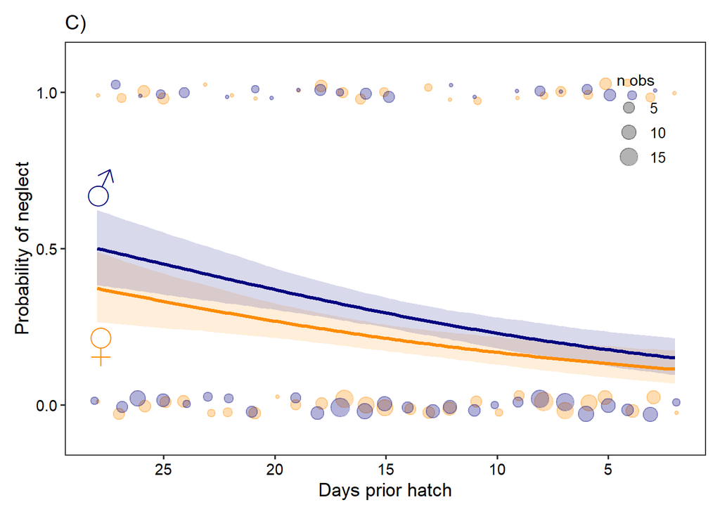

Probability of any neglect per day by sex across incubation

```r
plot_occ <- data.frame(
  day = DAY_SEQ,
  f_mu = mu_f_occ, f_low = PI_f_occ[1,], f_high = PI_f_occ[2,],
  m_mu = mu_m_occ, m_low = PI_m_occ[1,], m_high = PI_m_occ[2,]
)

post_samples_occ <- sim(m_occ, data = d_occ)#


D_occ$post_any_neglect <- post_samples_occ[1, ]

ggplot() +

  geom_ribbon(data = plot_occ,
              aes(x = day, ymin = f_low, ymax = f_high),
              fill = col_female, alpha = 0.15) +
  geom_ribbon(data = plot_occ,
              aes(x = day, ymin = m_low, ymax = m_high),
              fill = col_male, alpha = 0.15) +

  # Mean Lines
  geom_line(data = plot_occ,
            aes(x = day, y = f_mu),
            color = col_female, linewidth = 1.2) +
  geom_line(data = plot_occ,
            aes(x = day, y = m_mu),
            color = col_male, linewidth = 1.2) +

  # Bubble Points - TERAZ Z POSTERIOR PREDICTIVE (0 lub 1)
  geom_count(data = D_occ,
             aes(x = day_prior_hatch,
                 y = post_any_neglect, # Zmienione na dane symulowane
                 color = as.factor(sex_id)),
             alpha = 0.3,
             # Dodajemy jitter, żeby bąbelki na 0 i 1 nie były "płaskimi" plackami
             position = position_jitter(width = 0.15, height = 0.03)) +

  # Manual Color Scales
  scale_color_manual(values = c("1" = col_female, "2" = col_male),
                     guide = "none") +

  # Sex Labels
  annotate("text", x = 27.8, y = 0.7,
           label = "\u2642", size = 10,
           color = col_male, fontface = "bold") +
  annotate("text", x = 27.8, y = 0.20,
           label = "\u2640", size = 10,
           color = col_female, fontface = "bold") +

  # Scaling and Labels
  scale_x_reverse(breaks = seq(0, 30, by = 5)) +
  # Dodajemy mały margines w coord_cartesian, żeby jitter nie "uciekał" poza oś
  coord_cartesian(ylim = c(-0.1, 1.1)) +
  scale_y_continuous(breaks = c(0, 0.5, 1)) +
  scale_size_continuous(name = "n obs", range = c(1, 6)) +
  labs(title = "C)", x = "Days prior hatch", y = "Probability of neglect") +

  # Theme
  theme_bw(base_size = 12, base_family = "sans") +
  theme(
    panel.grid = element_blank(),
    legend.position = c(0.90, 0.81),
    legend.background = element_blank(),
    legend.key = element_blank(),
    axis.title = element_text(size = 13),
    axis.text = element_text(size = 11, color = "black"),
    legend.title = element_text(size = 11),
    legend.text = element_text(size = 10),
    plot.margin = margin(10, 10, 10, 10)
  )
```

## 2.3 Duration of neglect (given neglect occurred)

To capture how long neglect episodes last when they do occur, we modelled total neglect duration on the log scale using a Gaussian GLM, restricted to days where neglect was recorded. This forms the second component of the hurdle model — separating the question of *whether* neglect happens from *how severe* it is when it does.

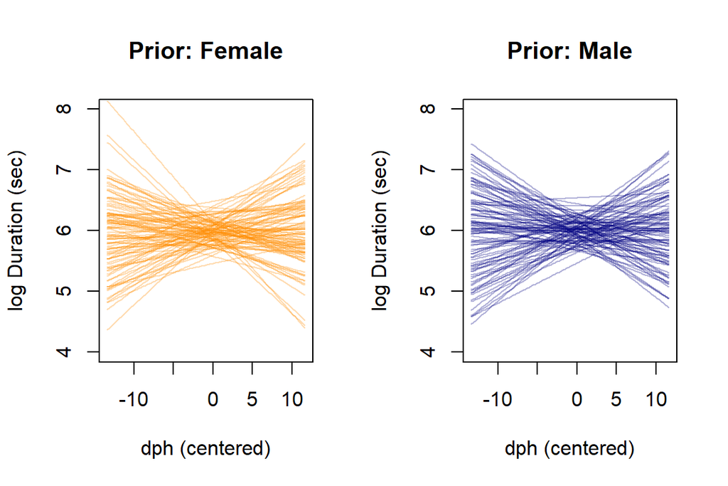

Prior predictive simulation for neglect duration model

```r
set.seed(42)
dph_grid_dur <- seq(min(D_dur$dph_c), max(D_dur$dph_c), length.out = 100)

prior_f_dur <- matrix(NA, nrow = n_sim, ncol = length(dph_grid_dur))
prior_m_dur <- matrix(NA, nrow = n_sim, ncol = length(dph_grid_dur))

for(i in 1:n_sim){
  a <- rnorm(2, 6, 0.2)
  b <- rnorm(2, 0, 0.05)
  prior_f_dur[i,] <- a[1] + b[1] * dph_grid_dur  # no exp() here
  prior_m_dur[i,] <- a[2] + b[2] * dph_grid_dur  # no exp() here
}

par(mfrow = c(1, 2))
matplot(dph_grid_dur, t(prior_f_dur), type = "l", lty = 1,
        col = col.alpha("darkorange", 0.3),
        ylim = c(4, 8),          # log scale limits (exp(12) ~ 160,000 sec)
        xlab = "dph (centered)", ylab = "log Duration (sec)",
        main = "Prior: Female")
matplot(dph_grid_dur, t(prior_m_dur), type = "l", lty = 1,
        col = col.alpha("navyblue", 0.3),
        ylim = c(4, 8),
        xlab = "dph (centered)", ylab = "log Duration (sec)",
        main = "Prior: Male")
```

```r
par(mfrow = c(1, 1))
```

```r
cat("Female slope:", round(mean(post_dur_samp$b[,1]), 4),
    " PI:", round(PI(post_dur_samp$b[,1]), 4),
    " P(<0):", round(mean(post_dur_samp$b[,1] < 0), 3), "\n")
```

```
## Female slope: 0.0633  PI: 0.0344 0.0934  P(<0): 0
```

```r
cat("Male slope:  ", round(mean(post_dur_samp$b[,2]), 4),
    " PI:", round(PI(post_dur_samp$b[,2]), 4),
    " P(<0):", round(mean(post_dur_samp$b[,2] < 0), 3), "\n")
```

```
## Male slope:   0.0638  PI: 0.0368 0.0915  P(<0): 0
```

```r
cat("Mean duration diff (F-M, sec):", round(mean(dur_diff), 1),
    " PI:", round(PI(dur_diff), 1), "\n")
```

```
## Mean duration diff (F-M, sec): -38  PI: -140.1 62.7
```

```r
cat("P(Female > Male baseline):", round(mean(post_dur_samp$a[,1] > post_dur_samp$a[,2]), 3), "\n")
```

```
## P(Female > Male baseline): 0.275
```

When neglect did occur, its duration also changed over time. Again, given the reversed scale, the positive slopes (female: 0.0633; male: 0.0638) indicate that neglect duration decreases toward hatching (female PI [0.0344, 0.0934]; male PI [0.0368, 0.0915]; both P(slope < 0) = 0). This shows that not only does neglect become less frequent, but individual events also become shorter as hatching approaches.

There was no credible sex difference in duration. The mean baseline difference was −38 seconds (89% PI [−140.1, 62.7]; P(Female > Male) = 0.275), indicating substantial overlap between sexes.

Taken together, the hurdle model reveals an important asymmetry: the sex difference in neglect is primarily driven by whether they neglect at all, rather than by differences in how long neglect lasts once it begins. Both components decline toward hatching, pointing to a shared increase in parental commitment as the critical hatching window approaches.

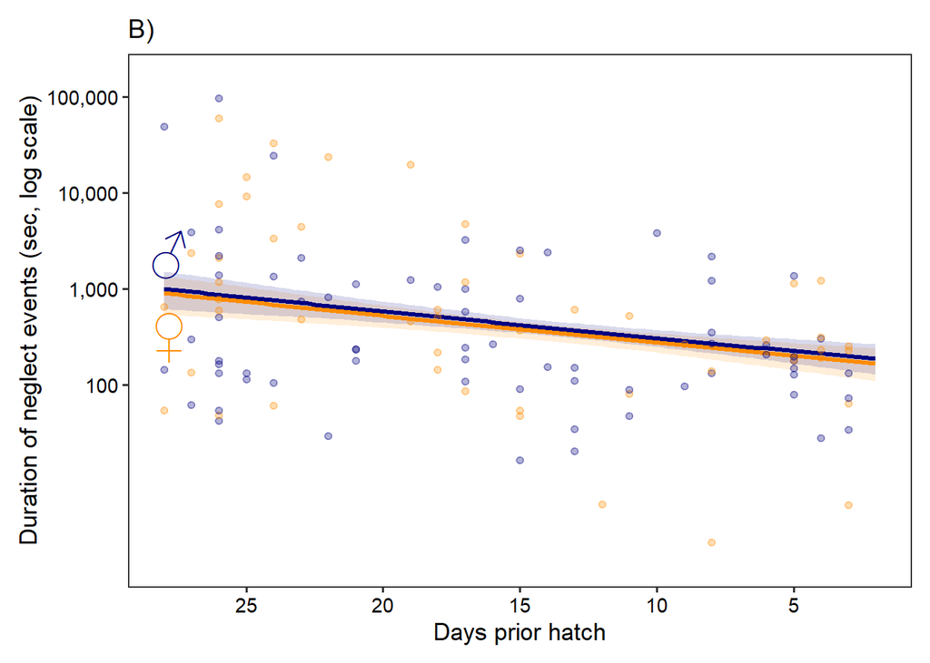

Total neglect duration (seconds, log scale) given neglect occurred, by sex across incubation

```r
post_samples_log_dur <- sim(m_dur, data = d_dur)


D_dur$post_sum_neglect_sec <- exp(post_samples_log_dur[1, ])

plot_df <- data.frame(
  day = DAY_SEQ,
  f_mu = mu_f_dur, f_low = PI_f_dur[1,], f_high = PI_f_dur[2,],
  m_mu = mu_m_dur, m_low = PI_m_dur[1,], m_high = PI_m_dur[2,]
)

ggplot() +
  geom_ribbon(data = plot_df,
              aes(x = day, ymin = f_low, ymax = f_high),
              fill = col_female, alpha = 0.15) +
  geom_ribbon(data = plot_df,
              aes(x = day, ymin = m_low, ymax = m_high),
              fill = col_male, alpha = 0.15) +

  # 2. Regression Lines
  geom_line(data = plot_df,
            aes(x = day, y = f_mu),
            color = col_female, linewidth = 1.2) +
  geom_line(data = plot_df,
            aes(x = day, y = m_mu),
            color = col_male, linewidth = 1.2) +

  # 3. Bubble Points - TERAZ Z POSTERIOR PREDICTIVE
  # geom_count automatycznie pogrupuje podobne wartości symulowane
  geom_count(data = D_dur,
             aes(x = day_prior_hatch,
                 y = post_sum_neglect_sec,
                 color = as.factor(sex_id)),
             alpha = 0.3) +

  # 4. Sex Annotations
  annotate("text", x = 27.8, y = plot_df$m_mu[100] * 2.4,
           label = "\u2642", size = 10, color = col_male, fontface = "bold", family = "sans") +
  annotate("text", x = 27.8, y = plot_df$f_mu[100] * 0.4,
           label = "\u2640", size = 10, color = col_female, fontface = "bold", family = "sans") +

# 5. Scales and Labels
scale_color_manual(values = c("1" = col_female, "2" = col_male), guide = "none") +

  scale_size_continuous(range = c(0.5, 2), guide = "none") +

  scale_y_log10(
    breaks = c(100, 1000, 10000, 100000),
    labels = scales::label_comma(),
    expand = expansion(mult = c(0.1, 0.1))
  ) +
  scale_x_reverse(breaks = seq(0, 30, by = 5)) +
  labs(title = "B)",
       x = "Days prior hatch",
       y = "Duration of neglect events (sec, log scale)") +

  # 7. Theme
  theme_bw(base_size = 12, base_family = "sans") +
  theme(
    panel.grid = element_blank(),
    legend.position = "none", # Najpewniejszy sposób na usunięcie wszystkich legend
    axis.title = element_text(size = 13),
    axis.text = element_text(size = 11, color = "black"),
    plot.margin = margin(10, 10, 10, 10)
  )
```

# 3 Neglect behaviour in relation to pair status and similarity

In this section we examine whether pair experience (new vs. established pairs) and pair similarity predict neglect behaviour. We model both gap frequency and total neglect duration for each predictor separately, using a hurdle approach — the frequency model includes all observations, while the duration model is restricted to days where neglect was recorded.

## 3.1 Pair status

We modelled gap frequency using a Poisson GLM and neglect duration using a Normal GLM on the log scale, both with pair status (New vs. Old) as a binary predictor and session as an index variable to account for repeated measures across incubation. Due to low sample size, all three sessions were included in this analysis.

$$\begin{aligned}
N_i &\sim \text{Poisson}(\lambda_i) \\
\log(\lambda_i) &= \alpha_{pair[i]} + \beta_1 \cdot dph\_c_i \\
\alpha_j &\sim \text{Normal}(0,\, 0.8) \\
\beta_1 &\sim \text{Normal}(0,\, 0.5)
\end{aligned}$$

$$\begin{aligned}
\log(D_i) &\sim \text{Normal}(\mu_i,\, \sigma) \\
\mu_i &= \alpha_{pair[i]} + \beta_1 \cdot dph\_c_i \\
\alpha_j &\sim \text{Normal}(6,\, 0.5) \\
\beta_1 &\sim \text{Normal}(0,\, 0.5) \\
\sigma &\sim \text{Exponential}(1)
\end{aligned}$$
Where $\text{pair}_{01}$ is a binary indicator (0 = New, 1 = Old) and session $j$ captures variation across incubation stages.

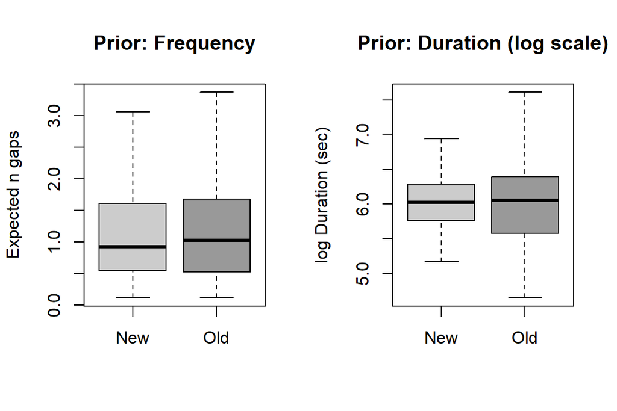

Prior predictive simulation for pair status models

```r
set.seed(42)
n_sim <- 100

prior_freq_new <- prior_freq_old <- numeric(n_sim)
prior_dur_new  <- prior_dur_old  <- numeric(n_sim)

for(i in 1:n_sim){
  a   <- rnorm(1, 0, 0.8)
  b   <- rnorm(1, 0, 0.5)
  prior_freq_new[i] <- exp(a)
  prior_freq_old[i] <- exp(a + b)

  a_d <- rnorm(1, 6, 0.5)
  b_d <- rnorm(1, 0, 0.5)
  prior_dur_new[i] <- a_d
  prior_dur_old[i] <- a_d + b_d
}

par(mfrow = c(1, 2))
boxplot(list(New = prior_freq_new, Old = prior_freq_old),
        col = c("gray80", "gray60"),
        ylab = "Expected n gaps", main = "Prior: Frequency",
        outline = FALSE)
boxplot(list(New = prior_dur_new, Old = prior_dur_old),
        col = c("gray80", "gray60"),
        ylab = "log Duration (sec)", main = "Prior: Duration (log scale)",
        outline = FALSE)
```

```r
par(mfrow = c(1, 1))
```

```r
post_f <- extract.samples(m_status_freq)
post_d <- extract.samples(m_status_dur)

cat("\n--- PAIR STATUS RESULTS (Global Intercept) ---\n")
```

```
##
## --- PAIR STATUS RESULTS (Global Intercept) ---
```

```r
cat("FREQ: Rate ratio (Old/New):", round(mean(exp(post_f$b)), 3), " | 89% PI:", round(PI(exp(post_f$b)), 3), "\n")
```

```
## FREQ: Rate ratio (Old/New): 1.205  | 89% PI: 1.16 1.251
```

```r
cat("DUR:  Duration Ratio (Old/New):", round(mean(exp(post_d$b)), 3), " | 89% PI:", round(PI(exp(post_d$b)), 3), "\n")
```

```
## DUR:  Duration Ratio (Old/New): 1.154  | 89% PI: 0.46 2.242
```

```r
cat("DUR:  P(Old Duration > New Duration):", round(mean(post_d$b > 0), 3), "\n")
```

```
## DUR:  P(Old Duration > New Duration): 0.512
```

Pair experience significantly influenced the frequency of nest neglect, though its effect on the duration of neglect was less clear. Established pairs (Old) initiated neglect events more frequently than new pairs, with a rate ratio of 1.21 (89% PI [1.16, 1.25]). These results provide strong evidence that experienced pairs leave the nest more often than new pairs throughout the incubation period.

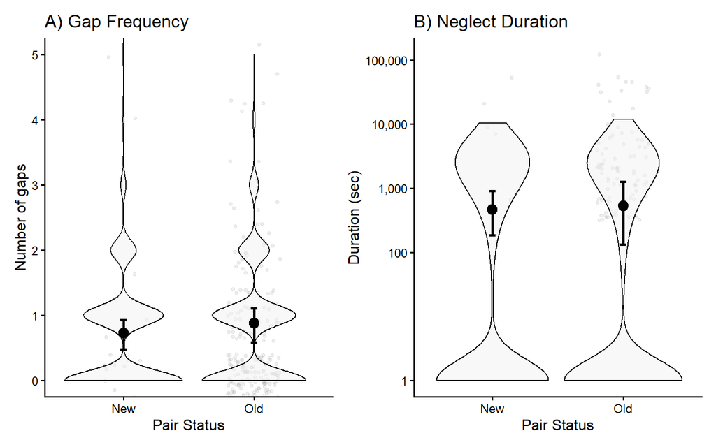

Gap frequency (A) and neglect duration (B) by pair status. Points show model estimates with 89% PI; violins and jittered points show raw data.

```r
df_post_d_clean <- df_post_d
df_post_d_clean$val[df_post_d_clean$val <= 0] <- 1 # Zamiana na 1s, by log10 działał

# --- Wykres A: Bez zmian (Poisson nie ma problemu z log) ---
p_freq <- ggplot() +
  geom_jitter(data = D_all, aes(x = factor(pair_01, labels=c("New", "Old")), y = n_gaps),
              width = 0.2, alpha = 0.2, size = 1, color = "gray70") +
  geom_violin(data = df_post_f, aes(x = Pair_status, y = val),
              fill = "gray95", color = "black", linewidth = 0.5, alpha = 0.5) +
  geom_errorbar(data = plot_freq_df, aes(x = status, ymin = low, ymax = high),
                width = 0.05, linewidth = 1, color = "black") +
  geom_point(data = plot_freq_df, aes(x = status, y = mu),
             size = 3.5, color = "black") +
  coord_cartesian(ylim = c(0, 5)) +
  labs(title = "A) Gap Frequency", x = "Pair Status", y = "Number of gaps") +
  theme_classic(base_size = 12)

# --- Wykres B: Poprawiony pod skalę logarytmiczną ---
p_dur <- ggplot() +
  geom_jitter(data = D_nonzero, aes(x = factor(pair_01, labels=c("New", "Old")), y = sum_gaps),
              width = 0.2, alpha = 0.2, size = 1, color = "gray70") +
  # Używamy wyczyszczonych danych (df_post_d_clean)
  geom_violin(data = df_post_d_clean, aes(x = Pair_status, y = val),
              fill = "gray95", color = "black", linewidth = 0.5, alpha = 0.5) +
  geom_errorbar(data = plot_dur_df, aes(x = status, ymin = low, ymax = high),
                width = 0.05, linewidth = 1, color = "black") +
  geom_point(data = plot_dur_df, aes(x = status, y = mu),
             size = 3.5, color = "black") +
  # Ustawienie limitów wewnątrz skali, by uniknąć wyrzucania punktów przez jitter
  scale_y_log10(labels = scales::label_comma(),
                breaks = c(1, 100, 1000, 10000, 100000)) +
  labs(title = "B) Neglect Duration", x = "Pair Status", y = "Duration (sec)") +
  theme_classic(base_size = 12)


# Połączenie wykresów
library(patchwork)
p_freq + p_dur
```

## 3.2 Pair similarity

We modelled gap frequency and neglect duration as a function of a continuous pair Similarity Index, using only the first incubation session as it showed the highest number of exits. No session index was needed here as only one session was included.

$$\begin{aligned}
N_i &\sim \text{Poisson}(\lambda_i) \\
\log(\lambda_i) &= \alpha + \beta \cdot \text{Similarity}_i \\
\alpha &\sim \text{Normal}(0,\, 0.8) \\
\beta &\sim \text{Normal}(0,\, 0.5)
\end{aligned}$$

$$\begin{aligned}
\log(D_i) &\sim \text{Normal}(\mu_i,\, \sigma) \\
\mu_i &= \alpha + \beta \cdot \text{Similarity}_i \\
\alpha &\sim \text{Normal}(6,\, 0.5) \\
\beta &\sim \text{Normal}(0,\, 0.5) \\
\sigma &\sim \text{Exponential}(1)
\end{aligned}$$

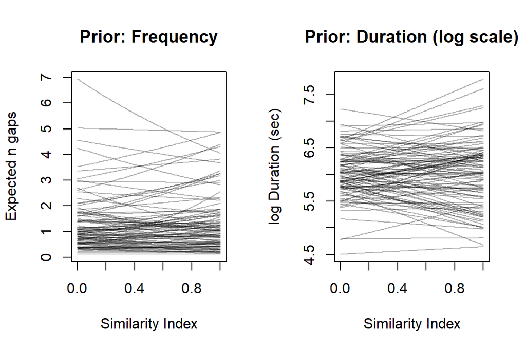

Prior predictive simulation for pair similarity models

```r
set.seed(42)
xseq_prior <- seq(0, 1, length.out = 100)

prior_sim_freq <- matrix(NA, nrow = n_sim, ncol = 100)
prior_sim_dur  <- matrix(NA, nrow = n_sim, ncol = 100)

for(i in 1:n_sim){
  a   <- rnorm(1, 0, 0.8); b   <- rnorm(1, 0, 0.5)
  prior_sim_freq[i,] <- exp(a + b * xseq_prior)

  a_d <- rnorm(1, 6, 0.5); b_d <- rnorm(1, 0, 0.5)
  prior_sim_dur[i,]  <- a_d + b_d * xseq_prior  # log scale
}

par(mfrow = c(1, 2))
matplot(xseq_prior, t(prior_sim_freq), type = "l", lty = 1,
        col = col.alpha("black", 0.3),
        xlab = "Similarity Index", ylab = "Expected n gaps",
        main = "Prior: Frequency")
matplot(xseq_prior, t(prior_sim_dur), type = "l", lty = 1,
        col = col.alpha("black", 0.3),
        xlab = "Similarity Index", ylab = "log Duration (sec)",
        main = "Prior: Duration (log scale)")
```

```r
par(mfrow = c(1, 1))
```

```r
cat("FREQ: Slope b:", round(mean(post_sim_f$b), 3),
    " 89% PI:", round(PI(post_sim_f$b), 3), "\n")
```

```
## FREQ: Slope b: 0.542  89% PI: 0.341 0.74
```

```r
cat("FREQ: P(slope > 0):", round(mean(post_sim_f$b > 0), 3), "\n")
```

```
## FREQ: P(slope > 0): 1
```

```r
cat("DUR:  Slope b:", round(mean(post_sim_d$b), 3),
    " 89% PI:", round(PI(post_sim_d$b), 3), "\n")
```

```
## DUR:  Slope b: 0.36  89% PI: -0.295 1.023
```

```r
cat("DUR:  P(slope > 0):", round(mean(post_sim_d$b > 0), 3), "\n")
```

```
## DUR:  P(slope > 0): 0.806
```

Gap frequency increased credibly with pair similarity, with a slope of 0.542 on the log scale (89% PI [0.341, 0.740]; P(slope > 0) = 1.0), indicating that more similar pairs initiated more frequent nest exits. This is a strong and consistent effect with no posterior probability supporting a negative relationship.

Neglect duration showed a weaker and less credible positive trend with similarity (slope: 0.360, 89% PI [−0.295, 1.023]; P(slope > 0) = 0.806), with the interval spanning zero. While the direction is consistent with the frequency result, the evidence is insufficient to conclude that more similar pairs also show longer neglect episodes when they do occur.

Taken together, pair similarity appears to primarily influence how often pairs neglect rather than how long those episodes last — a pattern that mirrors the sex differences observed earlier, where frequency was the more consistent axis of variation.

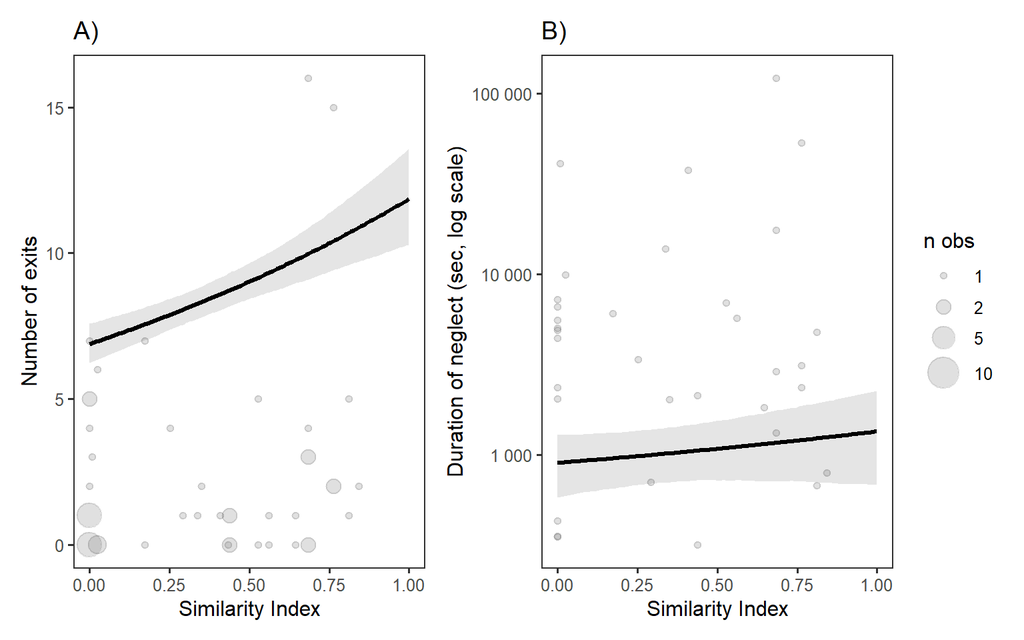

Gap frequency (A) and neglect duration (B) in relation to pair Similarity Index. Lines show posterior mean with 89% PI; bubble size indicates number of overlapping observations.

```r
shared_size_scale <- scale_size_continuous(
  name   = "n obs",
  range  = c(1.5, 8),
  limits = c(1, 10),
  breaks = c(1, 2, 5, 10)
)

p_sim_freq <- ggplot() +
  geom_count(data = D_sim, aes(x = Similarity_Index, y = n_gaps),
             alpha = 0.2, color = "gray40") +
  geom_ribbon(data = plot_sim_f, aes(x = x, ymin = low, ymax = high),
              fill = "black", alpha = 0.1) +
  geom_line(data = plot_sim_f, aes(x = x, y = mu),
            color = "black", linewidth = 1.2) +
  shared_size_scale +
  labs(title = "A)", x = "Similarity Index", y = "Number of exits") +
  theme_bw(base_size = 12, base_family = "sans") +
  theme(panel.grid = element_blank(),
        legend.background = element_blank())

p_sim_dur <- ggplot() +
  geom_count(data = D_sim_nonzero, aes(x = Similarity_Index, y = sum_gaps),
             alpha = 0.2, color = "gray40") +
  geom_ribbon(data = plot_sim_d, aes(x = x, ymin = low, ymax = high),
              fill = "black", alpha = 0.1) +
  geom_line(data = plot_sim_d, aes(x = x, y = mu),
            color = "black", linewidth = 1.2) +
  scale_y_log10(labels = scales::label_number()) +
  shared_size_scale +
  labs(title = "B)", x = "Similarity Index", y = "Duration of neglect (sec, log scale)") +
  theme_bw(base_size = 12, base_family = "sans") +
  theme(panel.grid = element_blank(),
        legend.background = element_blank())

p_sim_freq + p_sim_dur +
  plot_layout(guides = "collect") &
  theme(legend.position = "right")
```

# 4 Repeatability of neglect behaviour

To determine whether individuals are consistent in their tendency to neglect across incubation sessions, we estimated the repeatability of neglect occurrence using the `rptR` package. We modelled whether an individual neglected at all on a given observation (binary: 0/1) using a binomial repeatability model, with session as a fixed effect to account for the systematic change in neglect across incubation stages, and individual identity (`ringno`) as the grouping factor. This approach asks: after accounting for when in incubation the observation was made, is an individual consistently neglectful or not across all sessions in which it was observed? Repeatability was estimated using 1000 bootstrap iterations for confidence intervals and 1000 permutations for significance testing.

$$\begin{aligned}
\text{is_neglecting}_i &\sim \text{Binomial}(1,\, p_i) \\
\text{logit}(p_i) &= \beta \cdot \text{dph}_c,i + u_{ringno[i]} \\
u_{ringno} &\sim \text{Normal}(0,\, \sigma^2_{ringno})
\end{aligned}$$

Where repeatability $R$ is defined as the proportion of total phenotypic variance attributable to among-individual differences:

$$R =
\frac{\sigma^2_{ringno}}{\sigma^2_{ringno} +
\sigma^2_{residual}}$$

We estimated repeatability separately for the full dataset and for each sex, to test whether the consistency of neglect tendency differs between females and males.

Repeatability of individual neglect tendency across incubation sessions. Session included as fixed effect.

| Group | R (Link) | 95% CI (Link) | R (Original) | 95% CI (Original) | P (Permutation) |
| --- | --- | --- | --- | --- | --- |
| Overall | 0.247 | [0.116, 0.369] | 0.250 | [0.118, 0.408] | 0.001 |
| Males | 0.141 | [0.005, 0.301] | 0.145 | [0.005, 0.35] | 0.004 |
| Females | 0.262 | [0.063, 0.408] | 0.253 | [0.063, 0.432] | 0.001 |

Neglect tendency showed significant and consistent repeatability across incubation sessions. In the overall sample, individuals were moderately repeatable in whether they neglected at all, with a link-scale repeatability of R = 0.247 (95% CI [0.116, 0.369]; P = 0.001 by permutation test), and an original-scale estimate of R = 0.250 (95% CI [0.118, 0.408]). This indicates that a meaningful proportion of variation in neglect occurrence is attributable to stable among-individual differences, rather than being purely driven by session or chance.

Repeatability was significant in both sexes, though point estimates suggest that females may show higher individual consistency than males. Females had a link-scale repeatability of R = 0.262 (95% CI [0.063, 0.408]), compared to R = 0.141 (95% CI [0.005, 0.301]) in males, with both significant at P < 0.005 by permutation test. The confidence intervals of both sexes overlap substantially, so caution is warranted in interpreting this difference as biologically meaningful.

Taken together, these results suggest that neglect tendency is a repeatable individual trait in this population — some individuals consistently neglect across incubation sessions while others consistently do not.

# 5 Effect of neglect on incubation duration

To test whether the cumulative amount of neglect during incubation affects how long incubation lasts, we modelled incubation duration (days) as a function of total neglect accumulated across all three sessions. Only nests with complete data across all three incubation sessions were included, to ensure total neglect was not underestimated due to missing observations. Total neglect duration was log-transformed prior to fitting to address its right-skewed distribution, and then mean-centered.

$$\begin{aligned}
\text{Duration}_i &\sim \text{Normal}(\mu_i,\, \sigma) \\
\mu_i &= \alpha + \beta \cdot \log(\text{neglect})_{c,i} \\
\alpha &\sim \text{Normal}(29,\, 0.5) \\
\beta &\sim \text{Normal}(0,\, 0.5) \\
\sigma &\sim \text{Exponential}(1)
\end{aligned}$$

Where $\log(\text{neglect})_{c,i}$ is the log-transformed total neglect in seconds, mean-centered. The prior on $\alpha$ is centered at 29 days, consistent with the known incubation period of Little Auk. The prior on $\beta$ is centered at zero, reflecting no strong prior expectation about the direction of the effect.

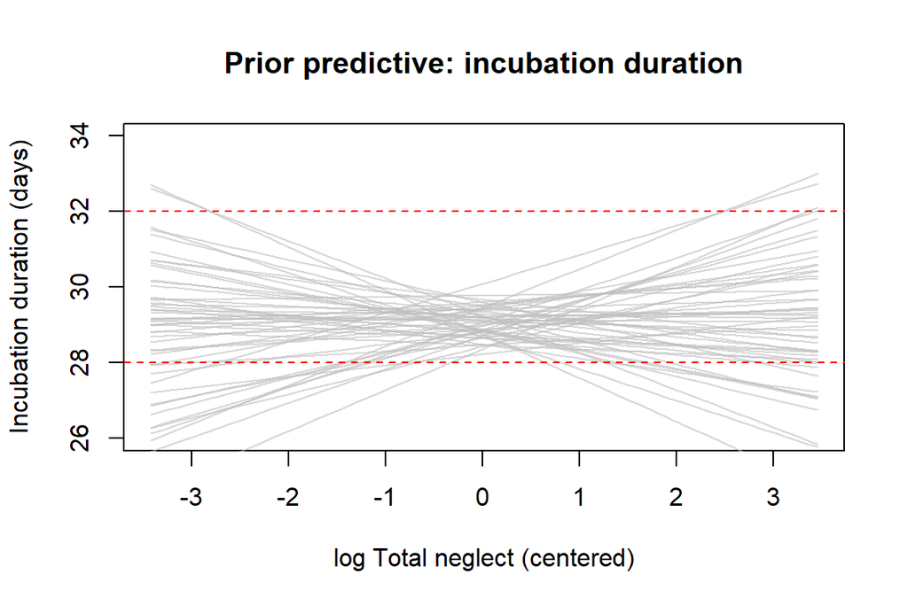

Prior predictive simulation for incubation duration model. Red dashed lines indicate the biologically plausible range of incubation duration in Little Auk.

```r
set.seed(123)
n_sim <- 50

plot(NULL, xlim = range(log_neglect_seq), ylim = c(26, 34),
     xlab = "log Total neglect (centered)",
     ylab = "Incubation duration (days)",
     main = "Prior predictive: incubation duration")
for(i in 1:n_sim){
  a <- rnorm(1, 29, 0.5)
  b <- rnorm(1, 0, 0.5)
  lines(log_neglect_seq, a + b * log_neglect_seq,
        col = col.alpha("grey", 0.6))
}
abline(h = c(28, 32), col = "red", lty = 2)
```

```r
print(precis(m_quap))
```

```
##             mean        sd        5.5%      94.5%
## a     29.1382123 0.1628692 28.87791581 29.3985088
## b      0.1551114 0.1042597 -0.01151586  0.3217386
## sigma  0.9660483 0.1181493  0.77722289  1.1548737
```

```r
post_inc <- extract.samples(m_quap)
cat("P(b > 0):", round(mean(post_inc$b > 0), 3), "\n")
```

```
## P(b > 0): 0.927
```

```r
cat("P(b < 0):", round(mean(post_inc$b < 0), 3), "\n")
```

```
## P(b < 0): 0.073
```

Total neglect accumulated across incubation showed a weak positive association with incubation duration, though the evidence was not conclusive. The posterior slope was 0.155 days per unit increase in log neglect (89% PI [−0.012, 0.322]; P(β > 0) = 0.927), with the interval just crossing zero. The intercept confirmed a mean incubation duration of 29.1 days (89% PI [28.9, 29.4]), consistent with the known biology of the species.

While most posterior weight supports a positive relationship — suggesting that nests accumulating more neglect tend toward slightly longer incubation — the uncertainty is substantial and the effect size is small. A one-unit increase in log neglect corresponds to a posterior mean increase of only 0.16 days. These results provide weak and inconclusive evidence that neglect prolongs incubation, and should be interpreted cautiously given the marginal credibility of the effect.

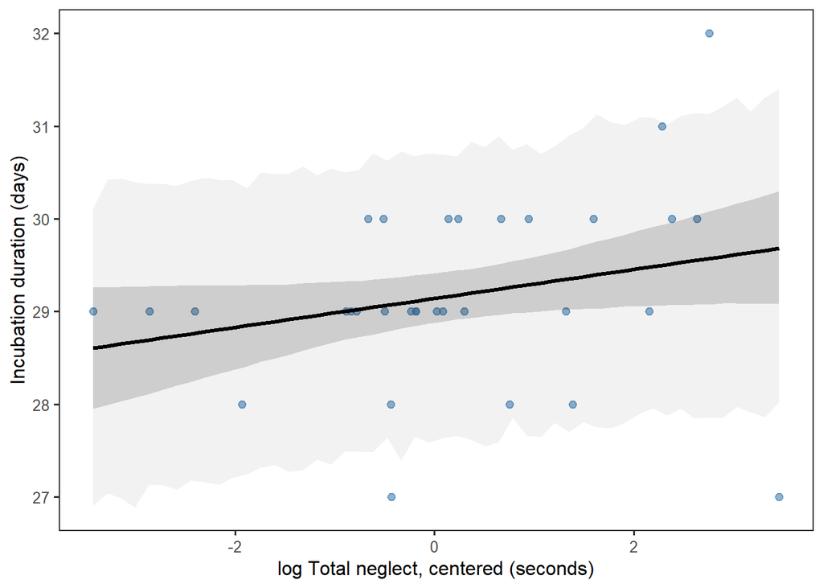

Incubation duration as a function of log total neglect accumulated across all three sessions. Line shows posterior mean; dark shading shows 89% PI of the mean; light shading shows 89% prediction interval.

```r
ggplot() +
  geom_point(data = nest_gaps,
             aes(x = log_neglect_c, y = incubation_duration),
             color = "steelblue", alpha = 0.6, size = 2) +
  geom_ribbon(aes(x = log_neglect_seq,
                  ymin = pred_PI[1,], ymax = pred_PI[2,]),
              fill = "black", alpha = 0.05) +
  geom_ribbon(aes(x = log_neglect_seq,
                  ymin = mu_PI[1,], ymax = mu_PI[2,]),
              fill = "black", alpha = 0.15) +
  geom_line(aes(x = log_neglect_seq, y = mu_mean),
            linewidth = 1.2, color = "black") +
  labs(x = "log Total neglect, centered (seconds)",
       y = "Incubation duration (days)") +
  theme_bw(base_size = 12, base_family = "sans") +
  theme(panel.grid = element_blank())
```

# 6 Seasonal differences in neglect behaviour

To examine whether neglect behaviour varied across breeding seasons, we modelled gap frequency, probability of neglect, and neglect duration separately for each season. All three models included season-specific intercepts to allow the baseline level of neglect to vary between seasons, while a shared slope captured the common trajectory of neglect across incubation days.

## 6.1 Gap frequency

$$\begin{aligned}
N_i &\sim \text{Poisson}(\lambda_i) \\
\log(\lambda_i) &= \alpha_{season[i]} + \beta \cdot \text{dph}_c \\
\alpha_j &\sim \text{Normal}(1,\, 0.5) \\
\beta &\sim \text{Normal}(0,\, 0.05)
\end{aligned}$$

## 6.2 Probability of neglect

$$\begin{aligned}
Y_i &\sim \text{Binomial}(1,\, p_i) \\
\text{logit}(p_i) &= \alpha_{season[i]} + \beta \cdot \text{dph}_c
\\
\alpha_j &\sim \text{Normal}(0,\, 1) \\
\beta &\sim \text{Normal}(0,\, 0.2)
\end{aligned}$$

## 6.3 Duration of neglect (given neglect occurred)

$$\begin{aligned}
\log(D_i) &\sim \text{Normal}(\mu_i,\, \sigma) \\
\mu_i &= \alpha_{season[i]} + \beta \cdot \text{dph}_c \\
\alpha_j &\sim \text{Normal}(6,\, 0.5) \\
\beta &\sim \text{Normal}(0,\, 0.1) \\
\sigma &\sim \text{Exponential}(1)
\end{aligned}$$

Where $\text{dph}_c$ is days prior to hatch, mean-centered. Season-specific intercepts $\alpha_j$ capture differences in the overall level of neglect between years, while the shared slope $\beta$ assumes a common trajectory across incubation for all seasons.

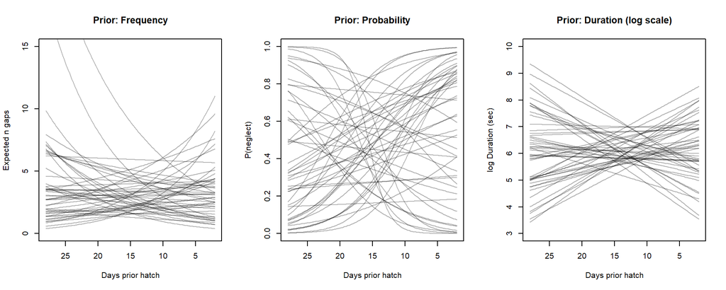

Prior predictive simulations for seasonal models.

```r
set.seed(123)
n_sim <- 50

par(mfrow = c(1, 3))

# Frequency prior
plot(NULL, xlim = c(28, 2), ylim = c(0, 15),
     xlab = "Days prior hatch", ylab = "Expected n gaps",
     main = "Prior: Frequency")
for(i in 1:n_sim){
  a <- rnorm(1, 1, 0.5); b <- rnorm(1, 0, 0.05)
  lines(day_seq, exp(a + b * dph_seq_c), col = col.alpha("black", 0.3))
}

# Occupancy prior
plot(NULL, xlim = c(28, 2), ylim = c(0, 1),
     xlab = "Days prior hatch", ylab = "P(neglect)",
     main = "Prior: Probability")
for(i in 1:n_sim){
  a <- rnorm(1, 0, 1); b <- rnorm(1, 0, 0.2)
  lines(day_seq, inv_logit(a + b * dph_seq_c), col = col.alpha("black", 0.3))
}

# Duration prior
plot(NULL, xlim = c(28, 2), ylim = c(3, 10),
     xlab = "Days prior hatch", ylab = "log Duration (sec)",
     main = "Prior: Duration (log scale)")
for(i in 1:n_sim){
  a <- rnorm(1, 6, 0.5); b <- rnorm(1, 0, 0.1)
  lines(day_seq, a + b * dph_seq_c, col = col.alpha("black", 0.3))
}
```

```r
par(mfrow = c(1, 1))
```

```r
cat("=== FREQUENCY COMPARISONS ===\n")
```

```
## === FREQUENCY COMPARISONS ===
```

```r
for(i in 1:(n_seasons - 1)){
  for(j in (i + 1):n_seasons){
    diff <- post_freq$a[,i] - post_freq$a[,j]
    cat(season_levels[i], "vs", season_levels[j],
        "| log diff:", round(mean(diff), 3),
        "| P(S1 > S2):", round(mean(diff > 0), 3), "\n")
  }
}
```

```
## 2019 vs 2020 | log diff: 0.222 | P(S1 > S2): 0.997
## 2019 vs 2021 | log diff: 0.288 | P(S1 > S2): 0.999
## 2019 vs 2023 | log diff: 0.41 | P(S1 > S2): 1
## 2019 vs 2025 | log diff: 0.868 | P(S1 > S2): 1
## 2020 vs 2021 | log diff: 0.065 | P(S1 > S2): 0.77
## 2020 vs 2023 | log diff: 0.187 | P(S1 > S2): 0.97
## 2020 vs 2025 | log diff: 0.646 | P(S1 > S2): 1
## 2021 vs 2023 | log diff: 0.122 | P(S1 > S2): 0.863
## 2021 vs 2025 | log diff: 0.58 | P(S1 > S2): 1
## 2023 vs 2025 | log diff: 0.458 | P(S1 > S2): 1
```

```r
cat("\n=== OCCUPANCY COMPARISONS ===\n")
```

```
##
## === OCCUPANCY COMPARISONS ===
```

```r
for(i in 1:(n_seasons - 1)){
  for(j in (i + 1):n_seasons){
    diff <- post_occ$a[,i] - post_occ$a[,j]
    cat(season_levels[i], "vs", season_levels[j],
        "| logit diff:", round(mean(diff), 3),
        "| P(S1 > S2):", round(mean(diff > 0), 3), "\n")
  }
}
```

```
## 2019 vs 2020 | logit diff: -0.256 | P(S1 > S2): 0.31
## 2019 vs 2021 | logit diff: -0.176 | P(S1 > S2): 0.381
## 2019 vs 2023 | logit diff: 0.155 | P(S1 > S2): 0.61
## 2019 vs 2025 | logit diff: 0.408 | P(S1 > S2): 0.792
## 2020 vs 2021 | logit diff: 0.08 | P(S1 > S2): 0.564
## 2020 vs 2023 | logit diff: 0.411 | P(S1 > S2): 0.787
## 2020 vs 2025 | logit diff: 0.664 | P(S1 > S2): 0.939
## 2021 vs 2023 | logit diff: 0.331 | P(S1 > S2): 0.728
## 2021 vs 2025 | logit diff: 0.584 | P(S1 > S2): 0.89
## 2023 vs 2025 | logit diff: 0.253 | P(S1 > S2): 0.696
```

```r
cat("\n=== DURATION COMPARISONS ===\n")
```

```
##
## === DURATION COMPARISONS ===
```

```r
for(i in 1:(n_seasons - 1)){
  for(j in (i + 1):n_seasons){
    diff <- post_dur$a[,i] - post_dur$a[,j]
    cat(season_levels[i], "vs", season_levels[j],
        "| log diff:", round(mean(diff), 3),
        "| P(S1 > S2):", round(mean(diff > 0), 3), "\n")
  }
}
```

```
## 2019 vs 2020 | log diff: -0.02 | P(S1 > S2): 0.472
## 2019 vs 2021 | log diff: -0.518 | P(S1 > S2): 0.088
## 2019 vs 2023 | log diff: -0.591 | P(S1 > S2): 0.075
## 2019 vs 2025 | log diff: 0.607 | P(S1 > S2): 0.952
## 2020 vs 2021 | log diff: -0.497 | P(S1 > S2): 0.073
## 2020 vs 2023 | log diff: -0.571 | P(S1 > S2): 0.064
## 2020 vs 2025 | log diff: 0.627 | P(S1 > S2): 0.974
## 2021 vs 2023 | log diff: -0.074 | P(S1 > S2): 0.423
## 2021 vs 2025 | log diff: 1.124 | P(S1 > S2): 0.999
## 2023 vs 2025 | log diff: 1.198 | P(S1 > S2): 0.999
```

```r
cat("\n=== GLOBAL SLOPES ===\n")
```

```
##
## === GLOBAL SLOPES ===
```

```r
cat("Frequency slope b:", round(mean(post_freq$b), 4),
    " 89% PI:", round(PI(post_freq$b), 4),
    " P(b < 0):", round(mean(post_freq$b < 0), 3), "\n")
```

```
## Frequency slope b: 0.1651  89% PI: 0.1479 0.1822  P(b < 0): 0
```

```r
cat("Occupancy slope b:", round(mean(post_occ$b), 4),
    " 89% PI:", round(PI(post_occ$b), 4),
    " P(b < 0):", round(mean(post_occ$b < 0), 3), "\n")
```

```
## Occupancy slope b: 0.2119  89% PI: 0.1218 0.3005  P(b < 0): 0
```

```r
cat("Duration slope b: ", round(mean(post_dur$b), 4),
    " 89% PI:", round(PI(post_dur$b), 4),
    " P(b < 0):", round(mean(post_dur$b < 0), 3), "\n")
```

```
## Duration slope b:  0.2218  89% PI: 0.1508 0.2922  P(b < 0): 0
```

Gap frequency differed substantially across seasons, with 2019 showing the highest baseline rate of nest exits and 2025 the lowest. The difference between 2019 and 2025 was the largest observed (log diff: 0.868; P(2019 > 2025) = 1.0), and 2019 was credibly higher than all other seasons (P > 0.997 in all comparisons). Differences among the remaining seasons were smaller and less certain, with 2020, 2021, and 2023 showing broadly similar frequency levels (P ranging from 0.77 to 0.97), though all were credibly higher than 2025 (P = 1.0 in all cases).

The probability of any neglect occurring on a given day showed weaker and less consistent seasonal differences than frequency. No pairwise comparison was fully credible, with posterior probabilities ranging from 0.31 to 0.939. The clearest signal was between 2020 and 2025 (logit diff: 0.664; P(2020 > 2025) = 0.939) and between 2021 and 2025 (logit diff: 0.584; P = 0.890), suggesting 2025 tended to have a lower probability of neglect, consistent with the frequency results. Seasons 2019, 2020, and 2021 were largely indistinguishable from each other in terms of neglect probability.

Neglect duration when it occurred showed a different pattern from frequency. The most notable contrasts involved 2025, which showed substantially shorter neglect episodes than 2021 (log diff: 1.124; P(2021 > 2025) = 0.999) and 2023 (log diff: 1.198; P(2023 > 2025) = 0.999). In contrast, 2019 and 2020 showed similar durations to each other (log diff: −0.020; P = 0.472) and were intermediate between the longer-duration seasons (2021, 2023) and the shorter-duration season (2025). Differences between 2019/2020 and 2021/2023 were suggestive but uncertain (P ranging from 0.064 to 0.088).

Across all three models, the global slope for days prior to hatch was positive and credible (frequency: β = 0.165, 89% PI [0.148, 0.182]; occupancy: β = 0.212, 89% PI [0.122, 0.301]; duration: β = 0.222, 89% PI [0.151, 0.292]; P(β < 0) = 0 in all cases), confirming that neglect — in all its dimensions — consistently declines as hatching approaches, and that this pattern is shared across all seasons.

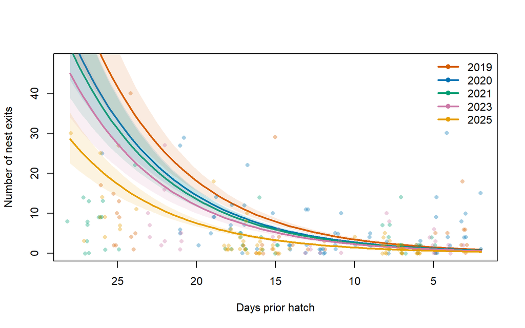

Expected number of nest exits per day by season across incubation. Lines show posterior mean with 89% PI.

```r
plot(NULL, xlim = c(28, 2),
     ylim = c(0, max(E_fit_season$n_gaps) * 1.2),
     xlab = "Days prior hatch", ylab = "Number of nest exits")
for(s in 1:n_seasons){
  idx <- E_fit_season$season == season_levels[s]
  points(jitter(E_fit_season$day_prior_hatch[idx], amount = 0.25),
         jitter(E_fit_season$n_gaps[idx], amount = 0.1),
         pch = 16, col = col.alpha(cols_season[s], 0.35), cex = 0.8)
  shade(PI_freq[[s]], day_seq, col = col.alpha(cols_season[s], 0.12))
  lines(day_seq, mu_freq[[s]], lwd = 2.5, col = cols_season[s])
}
legend("topright", legend = season_levels,
       col = cols_season[1:n_seasons], pch = 16, lwd = 2.5, bty = "n")
```

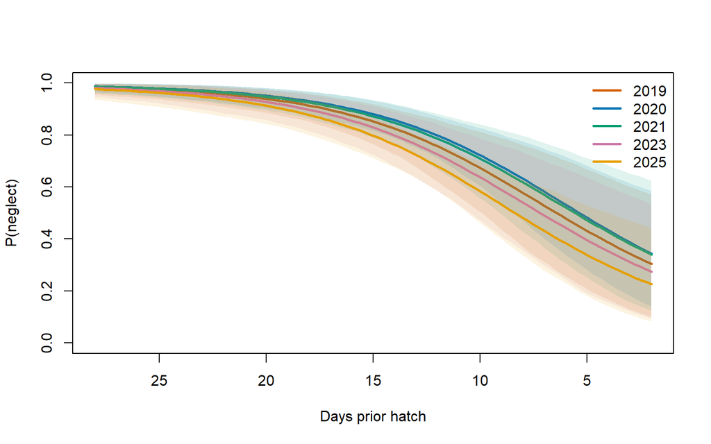

Probability of any neglect per day by season across incubation.

```r
plot(NULL, xlim = c(28, 2), ylim = c(0, 1),
     xlab = "Days prior hatch", ylab = "P(neglect)")
for(s in 1:n_seasons){
  shade(PI_occ[[s]], day_seq, col = col.alpha(cols_season[s], 0.12))
  lines(day_seq, mu_occ[[s]], lwd = 2.5, col = cols_season[s])
}
legend("topright", legend = season_levels,
       col = cols_season[1:n_seasons], lwd = 2.5, bty = "n")
```

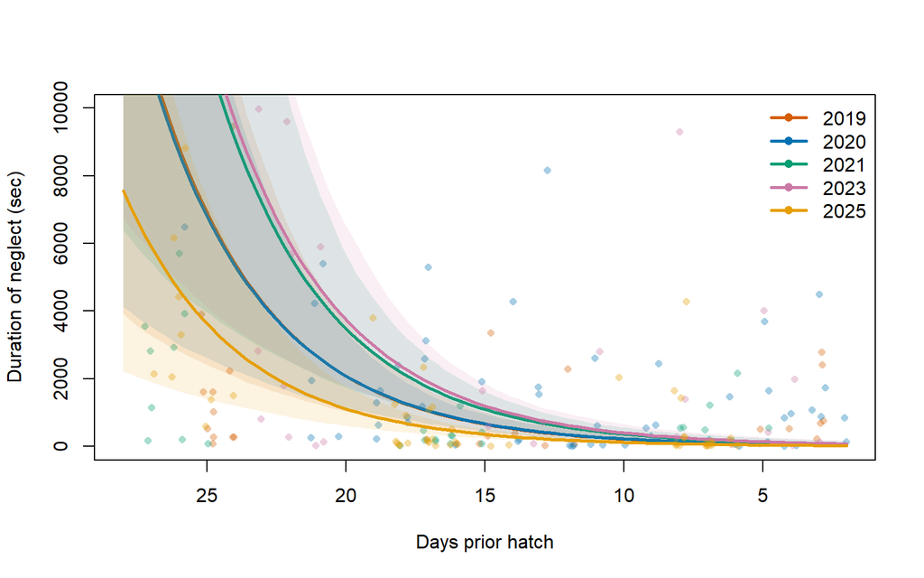

```r
plot(NULL, xlim = c(28, 2), ylim = c(0, 10000),
     xlab = "Days prior hatch", ylab = "Duration of neglect (sec)")
for(s in 1:n_seasons){
  idx <- E_pos$season == season_levels[s]
  points(jitter(E_pos$day_prior_hatch[idx], amount = 0.25),
         E_pos$sum_gaps[idx],
         pch = 16, col = col.alpha(cols_season[s], 0.35), cex = 0.8)
  shade(PI_dur[[s]], day_seq, col = col.alpha(cols_season[s], 0.12))
  lines(day_seq, mu_dur[[s]], lwd = 2.5, col = cols_season[s])
}
legend("topright", legend = season_levels,
       col = cols_season[1:n_seasons], pch = 16, lwd = 2.5, bty = "n")
```